# A3_DataExploration

**Course**: Data Visualization (Prof. Dr. Heike Leitte, Luisa Vollmer, RPTU Kaiserslautern), **Name**: Leyla B. Akıncı, **Date**: 07.01.2024

# Assignment 3 - Exploratory data analysis of the Titanic dataset

> The RMS Titanic was a British passenger liner that sank in the North Atlantic Ocean in the early morning hours of 15 April 1912, after it collided with an iceberg during its maiden voyage from Southampton to New York City. There were an estimated 2,224 passengers and crew aboard the ship, and more than 1,500 died, making it one of the deadliest commercial peacetime maritime disasters in modern history. The RMS Titanic was the largest ship afloat at the time it entered service and was the second of three Olympic-class ocean liners operated by the White Star Line. The Titanic was built by the Harland and Wolff shipyard in Belfast. Thomas Andrews, her architect, died in the disaster.

[figure not shown]

source: [wikipedia.org](https://en.wikipedia.org/wiki/RMS_Titanic)

### Outline and goals

In the third assignment, we will explore the titanic dataset using exploratory data analysis. The goals of this exercise are:

- conduct exploratory data analysis using python's seaborn library
- make a structured analysis (of a subset) of a given dataset
- contrast subgroups of data
- find patterns and outliers in data

**Important**: While no points will be awarded for typing the correct answers in the notebooks, it is highly advised to solve the tasks thoroughly. They are designed to be encouraging and provide you with valuable learnings for the exam, understanding of the methods and practical coding.

All tasks in this notebook are marked in green.

## 1. Load the data

```python
import pandas as pd
import numpy as np
import seaborn as sns
import matplotlib.pyplot as plt

titanic = sns.load_dataset("titanic")
titanic.head()
titanic.tail()
```

|  | survived | pclass | sex | age | sibsp | parch | fare | embarked | class | who | adult_male | deck | embark_town | alive | alone |
| --- | --- | --- | --- | --- | --- | --- | --- | --- | --- | --- | --- | --- | --- | --- | --- |
| 886 | 0 | 2 | male | 27.0 | 0 | 0 | 13.00 | S | Second | man | True | NaN | Southampton | no | True |
| 887 | 1 | 1 | female | 19.0 | 0 | 0 | 30.00 | S | First | woman | False | B | Southampton | yes | True |
| 888 | 0 | 3 | female | NaN | 1 | 2 | 23.45 | S | Third | woman | False | NaN | Southampton | no | False |
| 889 | 1 | 1 | male | 26.0 | 0 | 0 | 30.00 | C | First | man | True | C | Cherbourg | yes | True |
| 890 | 0 | 3 | male | 32.0 | 0 | 0 | 7.75 | Q | Third | man | True | NaN | Queenstown | no | True |

### Description of the titanic dataset:

survived - Survival (0 = No; 1 = Yes)  
plass - Passenger Class (1 = 1st; 2 = 2nd; 3 = 3rd)  
sex - Gender  
age - Age  
sibsp - Number of Siblings/Spouses Aboard  
parch - Number of Parents/Children Aboard  
fare - Passenger fare  
embarked - Port of Embarkation (C = Cherbourg; Q = Queenstown; S = Southampton)  
class - Class as string  
who - Type of person (child, man, woman)  
adult_male - Passenger is an adult male  
deck - Deck of passenger's accomodation  
embark_town - Port of Embarkation as string  
alive - Boolean  
alone - Person travelled alone

## 2. Get an overview

The command [`pandas.DataFrame.dtypes`](https://pandas.pydata.org/pandas-docs/stable/reference/api/pandas.DataFrame.dtypes.html) returns the data types as inferred by pandas.

Check if the inferred types match with the ones you would have assigned to each column.

```python
titanic.dtypes
```

```
survived          int64
pclass            int64
sex              object
age             float64
sibsp             int64
parch             int64
fare            float64
embarked         object
class          category
who              object
adult_male         bool
deck           category
embark_town      object
alive            object
alone              bool
dtype: object
```

The command [`pandas.DataFrame.describe`](https://pandas.pydata.org/pandas-docs/stable/reference/api/pandas.DataFrame.describe.html) provides summary statistics for all attributes.

```python
titanic.describe(include="all").T
```

|  | count | unique | top | freq | mean | std | min | 25% | 50% | 75% | max |
| --- | --- | --- | --- | --- | --- | --- | --- | --- | --- | --- | --- |
| survived | 891.0 | NaN | NaN | NaN | 0.383838 | 0.486592 | 0.0 | 0.0 | 0.0 | 1.0 | 1.0 |
| pclass | 891.0 | NaN | NaN | NaN | 2.308642 | 0.836071 | 1.0 | 2.0 | 3.0 | 3.0 | 3.0 |
| sex | 891 | 2 | male | 577 | NaN | NaN | NaN | NaN | NaN | NaN | NaN |
| age | 714.0 | NaN | NaN | NaN | 29.699118 | 14.526497 | 0.42 | 20.125 | 28.0 | 38.0 | 80.0 |
| sibsp | 891.0 | NaN | NaN | NaN | 0.523008 | 1.102743 | 0.0 | 0.0 | 0.0 | 1.0 | 8.0 |
| parch | 891.0 | NaN | NaN | NaN | 0.381594 | 0.806057 | 0.0 | 0.0 | 0.0 | 0.0 | 6.0 |
| fare | 891.0 | NaN | NaN | NaN | 32.204208 | 49.693429 | 0.0 | 7.9104 | 14.4542 | 31.0 | 512.3292 |
| embarked | 889 | 3 | S | 644 | NaN | NaN | NaN | NaN | NaN | NaN | NaN |
| class | 891 | 3 | Third | 491 | NaN | NaN | NaN | NaN | NaN | NaN | NaN |
| who | 891 | 3 | man | 537 | NaN | NaN | NaN | NaN | NaN | NaN | NaN |
| adult_male | 891 | 2 | True | 537 | NaN | NaN | NaN | NaN | NaN | NaN | NaN |
| deck | 203 | 7 | C | 59 | NaN | NaN | NaN | NaN | NaN | NaN | NaN |
| embark_town | 889 | 3 | Southampton | 644 | NaN | NaN | NaN | NaN | NaN | NaN | NaN |
| alive | 891 | 2 | no | 549 | NaN | NaN | NaN | NaN | NaN | NaN | NaN |
| alone | 891 | 2 | True | 537 | NaN | NaN | NaN | NaN | NaN | NaN | NaN |

Which columns contain missing values, commonly NaN? Hint: Consider the 'count' row of `describe`.

What are the names of the different decks and how many people were assigned to each deck? Does every passenger have an assigned deck?

Hint: The method [`pandas.Series.value_counts`](https://pandas.pydata.org/pandas-docs/stable/reference/api/pandas.Series.value_counts.html) may be helpful.

```python
titanic["deck"].value_counts()
```

```
C    59
B    47
D    33
E    32
A    15
F    13
G     4
Name: deck, dtype: int64
```

```python
titanic["deck"].value_counts(dropna=False)
```

```
NaN    688
C       59
B       47
D       33
E       32
A       15
F       13
G        4
Name: deck, dtype: int64
```

The deck names are A, B, C, D, E, F, G. I used the value_counts method both including missing values and excluding and the outputs were not matching. This means in our data not every passenger has an assigned deck.

## 3. Analyze variables individually

First we look into some of the variables individually. We will not cover the entire dataset in detail which would exceed the scope of an assignment, but concentrate on some aspects of it.

**Hints**:

- [documentation of countplot](https://seaborn.pydata.org/generated/seaborn.countplot.html#seaborn.countplot)
- [list of seaborn plots](https://seaborn.pydata.org/api.html#relational-api)
- [Seaborn cheat sheet](https://s3.amazonaws.com/assets.datacamp.com/blog_assets/Python_Seaborn_Cheat_Sheet.pdf)

**Examples**:

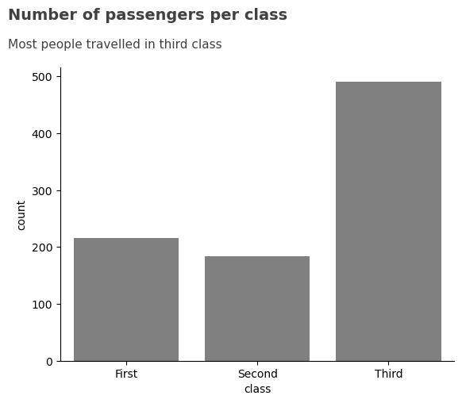

```python
ax = sns.countplot(x="class", data=titanic, color="gray")
ax.text(x=-.9, y=600, s="Number of passengers per class", fontsize=14, fontweight='semibold', color='#414141')
ax.text(x=-.9, y=550, s="Most people travelled in third class", fontsize=11, fontweight='normal', color='#414141')
sns.despine()
```

Finish the histogram below. - Set an appropriate number of bins and add a subtitle that tells about one finding. - Can you detect different price groups?

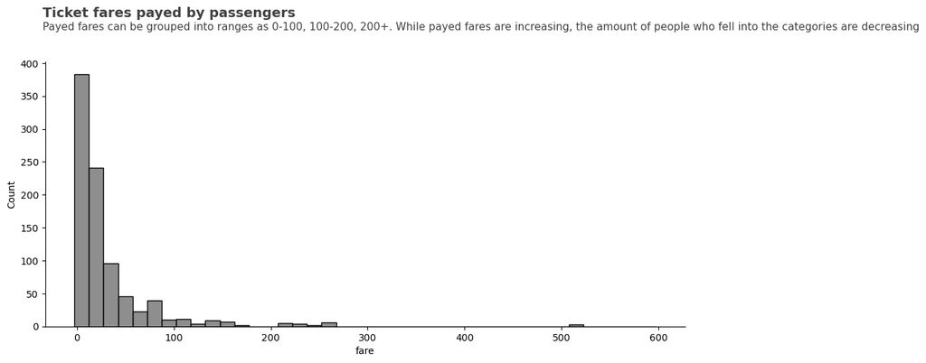

```python
fig, ax = plt.subplots(figsize=(12,5))
ax = sns.histplot(data=titanic["fare"], color="dimgray", bins=np.arange(-2.5,600,15))
ax.text(x=-35, y=470, s="Ticket fares payed by passengers", fontsize=14, fontweight='semibold', color='#414141')
ax.text(x=-35, y=450
        , s="Payed fares can be grouped into ranges as 0-100, 100-200, 200+. While payed fares are increasing, the amount of people who fell into the categories are decreasing"
        , fontsize=11, fontweight='normal', color='#414141')
sns.despine()
```

Select two columns/variables from the dataset and plot each with an appropriate chart (= two 1D-histograms, explore more if you want). Check that chart parameters are set appropriately. Add a matching title to your charts and state one finding in the subtitle.

```python
list(titanic)
```

```
['survived',
 'pclass',
 'sex',
 'age',
 'sibsp',
 'parch',
 'fare',
 'embarked',
 'class',
 'who',
 'adult_male',
 'deck',
 'embark_town',
 'alive',
 'alone']
```

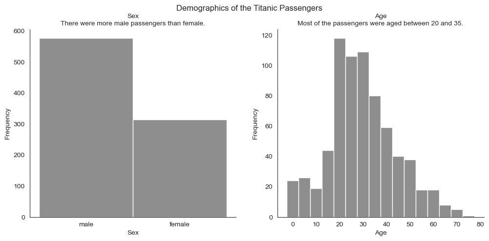

```python
sns.set_style("white")

fig, (ax1, ax2) = plt.subplots(1, 2, figsize=(12,5))
fig.suptitle('Demographics of the Titanic Passengers')
ax1 = sns.histplot(data=titanic["sex"], color="dimgray", bins=np.arange(-2.5,80), ax=ax1)
ax2 = sns.histplot(data=titanic["age"], color="dimgray", bins=np.arange(-2.5,80,5), ax=ax2)
ax1.set_title("Sex\nThere were more male passengers than female.", loc="center", fontsize=10)
ax1.set_xlabel("sex".capitalize())
ax1.set_ylabel("Frequency")
ax2.set_title("Age\nMost of the passengers were aged between 20 and 35.", loc="center", fontsize=10)
ax2.set_xlabel("age".capitalize())
ax2.set_ylabel("Frequency")

sns.despine()
```

## 4. Who did survive?

For each question below, create a chart in the axes above that helps you answer the questions. It is ok to stick to the [plots implemented in seaborn](https://seaborn.pydata.org/api.html). Some plots, like stacked bar charts, require more work.

Who had the highest chance of survival: men, women, or children? Hint: You can add another dimension to you `displot` or `countplot` by coloring bars with 'hue=column_name'.

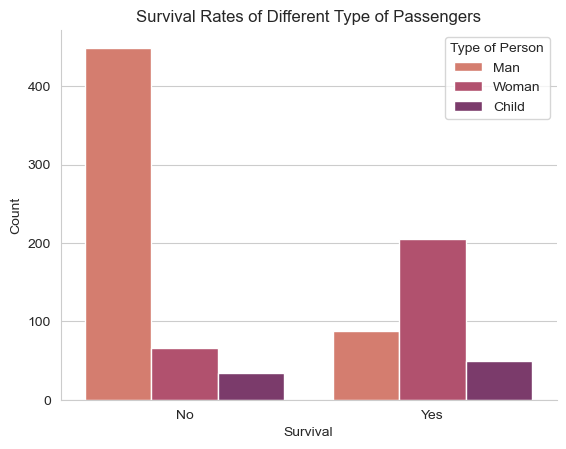

```python
#Adjusting background to make the counts easily trackable
sns.set_style("whitegrid")

ax = sns.countplot(x='survived', hue=titanic["who"], data=titanic, palette="flare")
ax.set_xticklabels(["No", "Yes"])

ax.set_title('Survival Rates of Different Type of Passengers')
ax.set_xlabel('Survival')
ax.set_ylabel('Count')

ax.legend(title="Type of Person", labels=["Man", "Woman", "Child"])

sns.despine();
```

Did age have an influence? Compare the age of people who survived and those who did not. Is your observation consistent for all three types of people (men, women, children)?

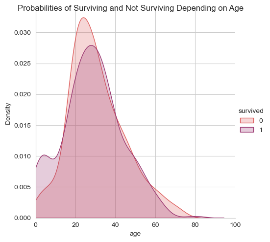

```python
#A plot that shows probability density of survival depending on age, without looking at the gender.
g = sns.FacetGrid(titanic, hue = "survived", height = 5, xlim = (0, 100), palette="flare").map(sns.kdeplot, "age", fill = True).add_legend()
g.fig.suptitle("Probabilities of Surviving and Not Surviving Depending on Age");
```

*When probability densities of surviving and not surviving compared, there are three age groups standing out that seemingly has a disposition towards one of the two consequences. Roughly the age group of 0-10 had a higher chance of surviving, the age group of 18-32 had a higher chance of not surviving, and lastly the age group of 60-80 had also a higher chance of not surviving.*

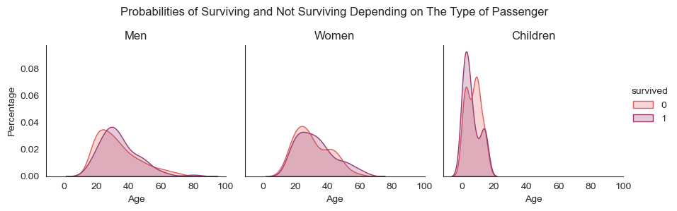

```python
sns.set_style("white")

g = sns.FacetGrid(titanic, col="who", hue="survived", palette="flare")
g.map(sns.kdeplot, "age", fill=True)
hue_labels = ['No', 'Yes']
g.add_legend()
g.fig.subplots_adjust(top=0.8)
g.fig.suptitle("Probabilities of Surviving and Not Surviving Depending on The Type of Passenger")
g.set_axis_labels(x_var="Age", y_var="Percentage")
axes = g.axes.flatten()
axes[0].set_title("Men")
axes[1].set_title("Women")
axes[2].set_title("Children");
```

**Did people on all decks have the same survival rate?**

The probabilities of survival and death can be computed as follows. We count the total number of people in each group ([`pandas.Series.value_counts`](https://pandas.pydata.org/pandas-docs/stable/reference/api/pandas.Series.value_counts.html)) and divide by the total number of passengers:

```python
titanic['alive'].value_counts() / len(titanic)
```

```
no     0.616162
yes    0.383838
Name: alive, dtype: float64
```

We see that the total survival rate was 38%.

To do the same for each deck, we first to handle NaN-values in the deck entries. We add a new column, that has a categorical entry "None" for all passengers with an unspecified deck entry:

```python
titanic['deck_all'] = titanic['deck'].cat.add_categories("None").fillna("None")
```

Now compute the survival rates per deck and plot the resulting series using, for example, [`seaborn.barplot`](https://seaborn.pydata.org/generated/seaborn.barplot.html).

Hints:

- Pandas allows you to filter data. `titanic[ titanic['age'] > 10 ]` returns a series of all passengers that are older than 10 years. This can be used to filter only people that survived.
- You can divide a series by a series elementwise. `titanic['fare'] / titanic['age']` computes for each passanger the fraction fare divided by age (i.e. ticket price per year they lived - which is nonesense, but computable).

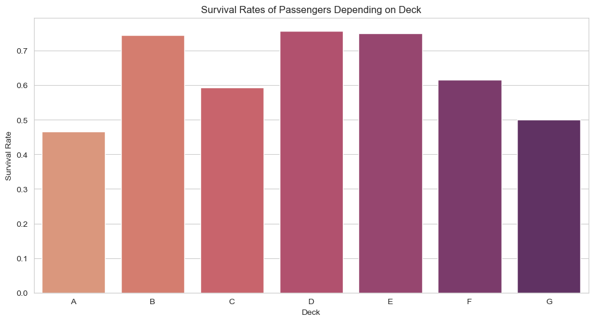

```python
sns.set_style("whitegrid")

survivors = titanic[titanic["survived"] == 1]
surv_rates = (survivors["deck"].value_counts() / titanic["deck"].value_counts()).sort_index()

plt.figure(figsize=(12, 6))
sns.barplot(x=surv_rates.index, y=surv_rates.values, palette='flare')
plt.title('Survival Rates of Passengers Depending on Deck')
plt.xlabel('Deck')
plt.ylabel('Survival Rate')
plt.show()
```

## 5. Fake news?

You talk to a friend about the titanic dataset and he/she says:

> It's so unfair. Only elderly people could afford First Class tickets and have a good trip on the Titanic.

Briefly discuss this statement. Write approximately 10-15 lines.

Hint:

- Explanation of **Discuss**: Essentially this is a written debate where you are using your skill at reasoning, backed up by carefully selected evidence to make a case for and against an argument, or point out the advantages and disadvantages of a given context. Remember to arrive at a conclusion. source (not necessary to read): [Essay terms explained by University of Leicester](https://www2.le.ac.uk/projects/oer/oers/ssds/oers/writing-skills/writingskillscg.pdf)

### Supporting charts:

```python
# suggestions: countplot, displot, histplot, scatterplot, boxplot, jointplot
```

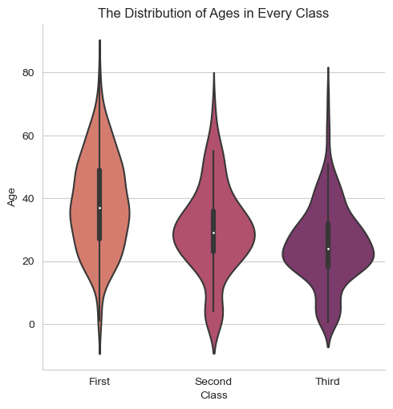

```python
#Here I used violin graph to show categorical distributions.
sns.set_style("whitegrid")
plt.figure(figsize=(12, 8))
sns.catplot(x = "class", y = "age", kind = "violin", data = titanic, palette="flare")
plt.title('The Distribution of Ages in Every Class')
plt.xlabel('Class')
plt.ylabel('Age')
plt.show()
```

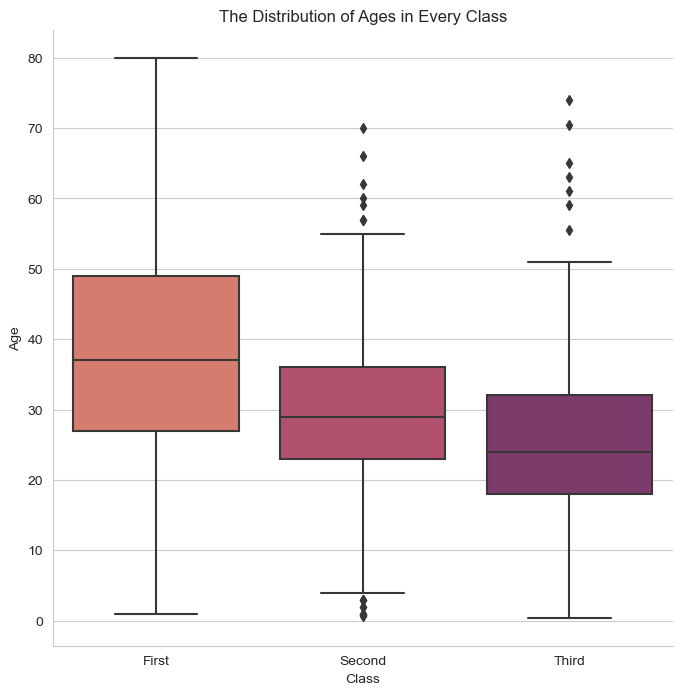

```python
sns.set_style("whitegrid")
plt.figure(figsize=(8, 8))
sns.boxplot(x="class", y="age", data=titanic, palette="flare")
plt.title('The Distribution of Ages in Every Class')
plt.xlabel("Class")
plt.ylabel("Age")
sns.despine()
plt.show()
```